# Dirichlet Processes

## Sethuraman’s construction of the Dirichlet process - stick-breaking definition

Simulation of trajectories of a Dirichlet process with parameter $(a, \alpha_0)$

Truncation of the infinite series and renormalization of the weights in Sethuraman’s representation

We fix the mean trajectory $\alpha_0$ equal to the standard Gaussian

We see what happens to the trajectories of the *truncated* DP as $a=1,100, 0.1$

```r
a=1 ##### TOTAL MASS parameter

M <- 500 # truncation level   M=1000 o M=500

install.packages("gsl")
install.packages(c("rbiutils", "gmp", "sets", "mathjaxr", "Rdpack", "Brobdingnag", "partitions", "polynom"))
```

$Y$ is the vector of the iid beta proportions in the stick-breaking

$\tau$ contains the support points of the DP, i.e. the $\tau_i$’s are iid from $\alpha_0={\mathcal N}(0,1)$

$V$ is the vector of the weights of the support points $\tau_i$’s

```r
install.packages("untb")
Y <- vector(length=M)
tau <-  vector(length=M)
V <- vector(length=M)
```

#### Simulation of the (truncated) trajectories

$P_M:= \sum_{j=1}^M \dfrac{V_j}{\sum_{j=1}^M V_j}\delta_{\tau_j}= \sum_{j=1}^M \widetilde V_j \delta_{\tau_j}$

```r
set.seed(13)  # let's fix the seed

Y <- rbeta(M,1,a) # Y_i's are beta(1,a)-distributed
tau <- rnorm(M,0,1) # simulated tau_i
cprod <- cumprod(1-Y)
cprod  <- c(1,cprod[1:M-1])
V <- Y*cprod   ## V_i = Y_i \prod_{j=1}^{i-1}(1-Y_j)

print(sum(V))  ## Compute the sum of all weights so far
```

```
[1] 1
```

```r
V <- V/sum(V)  ## Rinormalization of the weights (needed because truncation of the infinite series)
```

VISUALIZATION of the support points $(\tau_i)_{i\geq 1}$ and the weights $(V_i)_{i\geq 1}$, and $\alpha_0$

```r
curve(dnorm(x,0,1),from=-4,to=4,col="magenta",lwd=2,ylim=c(0,0.5),xlab=" ",ylab="",cex.axis=1.5) #mean parameter alpha_0 (in magenta)
abline(h=0,lty=2)
```

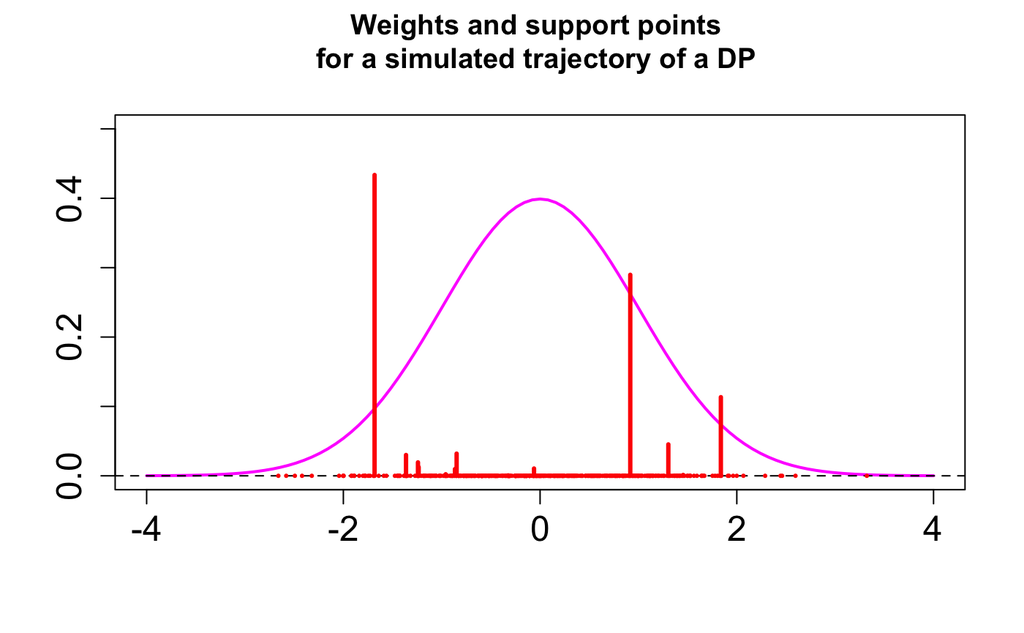

```r
lines(tau,V,"h",lwd=3,col="red")
title("Weights and support points \nfor a simulated trajectory of a DP \n ")
```

When $a$ is SMALL, there is one SINGLE LARGE weight (about 1); all the other weights are almost 0, so that we do NOT see them in the plot

When $a$ is LARGE, all the weights $V_i$’s are small, and their values are very similar

```r
sort(V,decreasing=T)[1:50]
```

```
 [1] 4.335564e-01 2.896776e-01 1.133511e-01 4.525854e-02 3.196029e-02 2.999080e-02 1.936184e-02 1.245794e-02 1.049925e-02
[10] 9.663132e-03 2.244426e-03 1.225067e-03 6.373435e-04 1.126910e-04 2.473723e-06 7.029515e-07 2.178374e-07 1.395617e-07
[19] 4.191146e-08 3.496929e-08 2.805137e-08 2.804860e-08 1.854981e-08 1.850915e-09 1.765679e-09 1.571583e-09 1.302939e-09
[28] 1.410452e-10 2.627380e-12 3.423737e-13 5.242099e-14 2.693398e-14 1.025850e-14 1.019298e-14 2.645252e-15 1.242783e-15
[37] 2.932172e-16 1.023690e-16 5.605249e-17 1.082242e-17 1.233076e-18 6.288345e-19 3.901417e-19 2.263552e-19 8.092422e-20
[46] 5.852648e-20 5.194752e-20 1.029965e-20 1.088260e-22 6.126296e-23
```

VISUALIZATION of the trajectory of the corresponding distribution function - it is easier to plot a df than a probability measure!

```r
oth <- order(tau)

curve(pnorm(x,0,1),from=-4,to=4,col="magenta",lwd=2,xlab=" ",ylab="",cex.axis=1.5) #magenta denotes the d.f. associated to alpha_0
lines(c(min(tau)-100,tau[oth],max(tau)+100),c(0,cumsum(V[oth]),1),type="s",col="red",lwd=3)
```

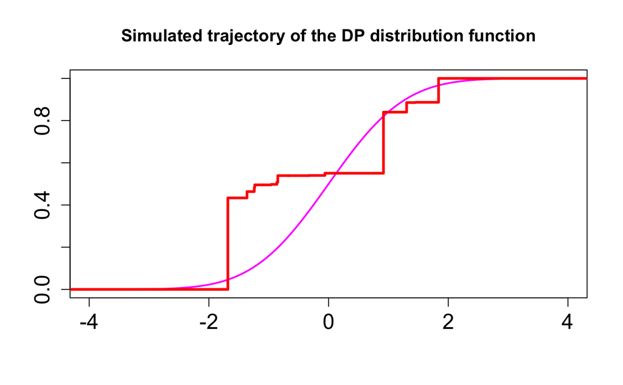

```r
title("Simulated trajectory of the DP distribution function")
```

TWO more trajectories

```r
oth <- order(tau)
curve(pnorm(x,0,1),from=-4,to=4,col="magenta",lwd=2,xlab=" ",ylab="",cex.axis=1.5) #magenta denotes the d.f. associated to alpha_0
lines(c(min(tau)-100,tau[oth],max(tau)+100),c(0,cumsum(V[oth]),1),type="s",col="red",lwd=3)
```

```r
title("Simulated trajectory of the DP distribution function")

set.seed(99)
Y <- rbeta(M,1,a)
tau <- rnorm(M,0,1)
cprod <- cumprod(1-Y)
cprod  <- c(1,cprod[1:M-1])
V <- Y*cprod
print(sum(V))
```

```
[1] 1
```

```r
V <- V/sum(V)
oth <- order(tau)
lines(c(min(tau)-100,tau[oth],max(tau)+100),c(0,cumsum(V[oth]),1),type="s",col="green",lwd=3)
```

```r
set.seed(76)
Y <- rbeta(M,1,a)
tau <- rnorm(M,0,1)
cprod <- cumprod(1-Y)
cprod  <- c(1,cprod[1:M-1])
V <- Y*cprod
print(sum(V))
```

```
[1] 1
```

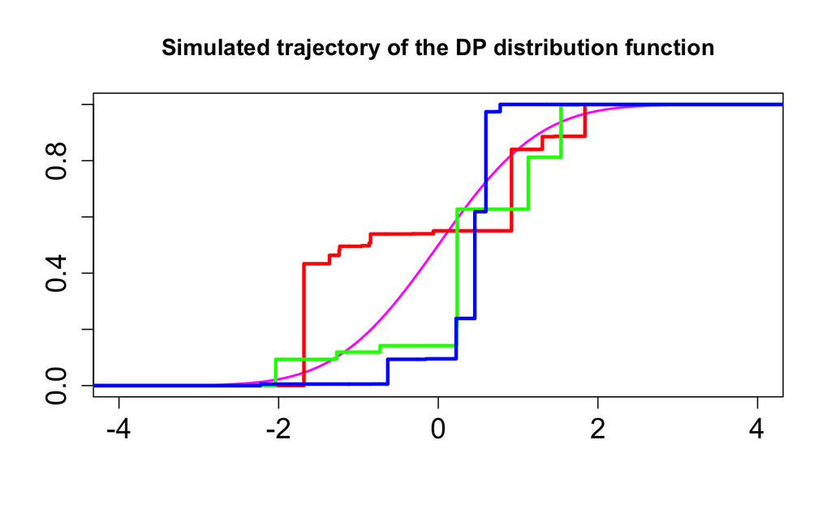

```r
V <- V/sum(V)
oth <- order(tau)
lines(c(min(tau)-100,tau[oth],max(tau)+100),c(0,cumsum(V[oth]),1),type="s",col="blue",lwd=3)
```

```r
oth <- order(tau)
curve(pnorm(x,0,1),from=-4,to=4,col="magenta",lwd=2,xlab=" ",ylab="",cex.axis=1.5) #magenta denotes the d.f. associated to alpha_0
lines(c(min(tau)-100,tau[oth],max(tau)+100),c(0,cumsum(V[oth]),1),type="s",col="red",lwd=3)
```

```r
title("Simulated trajectory of the DP distribution function")

set.seed(99)
Y <- rbeta(M,1,a)
tau <- rnorm(M,0,1)
cprod <- cumprod(1-Y)
cprod  <- c(1,cprod[1:M-1])
V <- Y*cprod
print(sum(V))
```

```
[1] 1
```

```r
V <- V/sum(V)
oth <- order(tau)
lines(c(min(tau)-100,tau[oth],max(tau)+100),c(0,cumsum(V[oth]),1),type="s",col="green",lwd=3)
```

```r
set.seed(76)
Y <- rbeta(M,1,a)
tau <- rnorm(M,0,1)
cprod <- cumprod(1-Y)
cprod  <- c(1,cprod[1:M-1])
V <- Y*cprod
print(sum(V))
```

```
[1] 1
```

```r
V <- V/sum(V)
oth <- order(tau)
lines(c(min(tau)-100,tau[oth],max(tau)+100),c(0,cumsum(V[oth]),1),type="s",col="blue",lwd=3)

### SAMPLING MANY trajectories of the DP df: we add them to the same plot
 gra=gray(1:100/100)
 gra=rep(gra,10)

for(j in 1:200){
set.seed(j)
Y <- rbeta(M,1,a)
tau <- rnorm(M,0,1)
cprod <- cumprod(1-Y)
cprod  <- c(1,cprod[1:M-1])
V <- Y*cprod
print(sum(V))
V <- V/sum(V)
oth <- order(tau)
lines(c(min(tau)-100,tau[oth],max(tau)+100),c(0,cumsum(V[oth]),1),type="s",col=gra[j])
}
```

```
[1] 1
[1] 1
[1] 1
[1] 1
[1] 1
[1] 1
[1] 1
[1] 1
[1] 1
[1] 1
[1] 1
[1] 1
[1] 1
[1] 1
[1] 1
```

[output cut: 185 more lines]

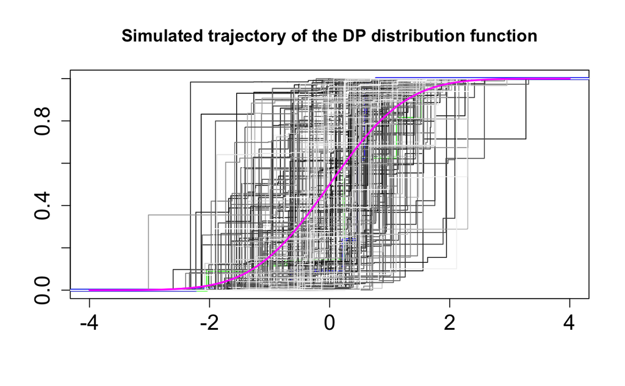

```r
curve(pnorm(x,0,1),from=-4,to=4,col="magenta",lwd=2,add=T)
```

What if we change the value of a?? a=0.1, a=100

Pay attention to sum(V)!

### Comparison of simulated trajectories for 3 different values of $a$

```r
a=0.5

M <- 500 #truncation level  M=500
Y <- vector(length=M)
tau <-  vector(length=M)
V <- vector(length=M)

Y <- rbeta(M,1,a)
tau <- rnorm(M,0,1)
cprod <- cumprod(1-Y)
cprod  <- c(1,cprod[1:M-1])
V <- Y*cprod
print(sum(V))
```

```
[1] 1
```

```r
V <- V/sum(V)


par(mfrow=c(1,3))
oth <- order(tau)
curve(pnorm(x,0,1),from=-4,to=4,col="magenta",lwd=2,xlab="",ylab="",cex.axis=1.5)
lines(c(min(tau)-100,tau[oth],max(tau)+100),c(0,cumsum(V[oth]),1),type="s",col="red",lwd=3)
```

```r
title("Total mass a=0.5")
gra=gray(1:100/100)
gra=rep(gra,10)

for(j in 1:50){
set.seed(j)
Y <- rbeta(M,1,a)
tau <- rnorm(M,0,1)
cprod <- cumprod(1-Y)
cprod  <- c(1,cprod[1:M-1])
V <- Y*cprod
print(sum(V))
V <- V/sum(V)
oth <- order(tau)
lines(c(min(tau)-100,tau[oth],max(tau)+100),c(0,cumsum(V[oth]),1),type="s",col=gra[j])
}
```

```
[1] 1
[1] 1
[1] 1
[1] 1
[1] 1
[1] 1
[1] 1
[1] 1
[1] 1
[1] 1
[1] 1
[1] 1
[1] 1
[1] 1
[1] 1
```

[output cut: 35 more lines]

```r
curve(pnorm(x,0,1),from=-4,to=4,col="magenta",lwd=2,add=T)

##
a=5
M <- 500 # truncation level   M=500
Y <- vector(length=M)
tau <-  vector(length=M)
V <- vector(length=M)

Y <- rbeta(M,1,a) #simulation of the beta rvs
tau <- rnorm(M,0,1) # tau_i iid from alpha_0= N(0,1)
cprod <- cumprod(1-Y)
cprod  <- c(1,cprod[1:M-1])
V <- Y*cprod
print(sum(V))
```

```
[1] 1
```

```r
V <- V/sum(V)


oth <- order(tau)
curve(pnorm(x,0,1),from=-4,to=4,col="magenta",lwd=2,xlab="",ylab="",cex.axis=1.5)
```

```r
lines(c(min(tau)-100,tau[oth],max(tau)+100),c(0,cumsum(V[oth]),1),type="s",col="red",lwd=3)
title("Total mass a=5")
```

```r
gra=gray(1:100/100)
gra=rep(gra,10)

for(j in 1:50){
set.seed(j)
Y <- rbeta(M,1,a)
tau <- rnorm(M,0,1)
cprod <- cumprod(1-Y)
cprod  <- c(1,cprod[1:M-1])
V <- Y*cprod
print(sum(V))
V <- V/sum(V)
oth <- order(tau)
lines(c(min(tau)-100,tau[oth],max(tau)+100),c(0,cumsum(V[oth]),1),type="s",col=gra[j])
}
```

```
[1] 1
[1] 1
[1] 1
[1] 1
[1] 1
[1] 1
[1] 1
[1] 1
[1] 1
[1] 1
[1] 1
[1] 1
[1] 1
[1] 1
[1] 1
```

[output cut: 35 more lines]

```r
curve(pnorm(x,0,1),from=-4,to=4,col="magenta",lwd=2,add=T)
```

```r
##
a=50
M <- 500 #
Y <- vector(length=M)
tau <-  vector(length=M)
V <- vector(length=M)

Y <- rbeta(M,1,a)
tau <- rnorm(M,0,1)
cprod <- cumprod(1-Y)
cprod  <- c(1,cprod[1:M-1])
V <- Y*cprod
print(sum(V))
```

```
[1] 0.9999484
```

```r
V <- V/sum(V)


oth <- order(tau)
curve(pnorm(x,0,1),from=-4,to=4,col="magenta",lwd=2,xlab="",ylab="",cex.axis=1.5)
lines(c(min(tau)-100,tau[oth],max(tau)+100),c(0,cumsum(V[oth]),1),type="s",col="red",lwd=3)
```

```r
title("Total mass a=50")
gra=gray(1:100/100)
gra=rep(gra,10)

for(j in 1:50){
set.seed(j)
Y <- rbeta(M,1,a)
tau <- rnorm(M,0,1)
cprod <- cumprod(1-Y)
cprod  <- c(1,cprod[1:M-1])
V <- Y*cprod
print(sum(V))
V <- V/sum(V)
oth <- order(tau)
lines(c(min(tau)-100,tau[oth],max(tau)+100),c(0,cumsum(V[oth]),1),type="s",col=gra[j])
}
```

```
[1] 0.9999571
[1] 0.9999162
[1] 0.9999809
[1] 0.9999787
[1] 0.9999582
[1] 0.9999694
[1] 0.9999362
[1] 0.99993
[1] 0.9999492
[1] 0.9999468
[1] 0.9999275
[1] 0.9999789
[1] 0.9999259
[1] 0.9999781
[1] 0.9999187
```

[output cut: 35 more lines]

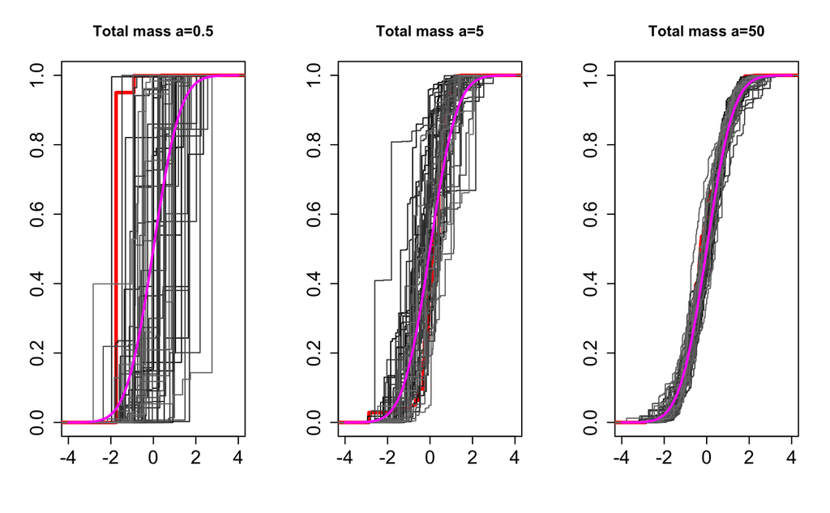

```r
curve(pnorm(x,0,1),from=-4,to=4,col="magenta",lwd=2,add=T,xlab="",ylab="",cex.axis=1.5)
```

## DIRECT sampling from a Dirichlet process

We simulate $Y_i$ iid from a truncated trajectory $P_M$

```r
a=1
M <- 100
Y <- vector(length=M)
tau <-  vector(length=M)
V <- vector(length=M)
# Simulation
Y <- rbeta(M,1,a)
tau <- rnorm(M,0,1)
cprod <- cumprod(1-Y)
cprod  <- c(1,cprod[1:M-1])
V <- Y*cprod
print(sum(V))
```

```
[1] 1
```

```r
V <- V/sum(V)
round(V,6)
```

```
  [1] 0.332578 0.250982 0.366541 0.046107 0.001626 0.001345 0.000454 0.000214 0.000111 0.000012 0.000005 0.000011 0.000009
 [14] 0.000001 0.000001 0.000003 0.000000 0.000000 0.000000 0.000000 0.000000 0.000000 0.000000 0.000000 0.000000 0.000000
 [27] 0.000000 0.000000 0.000000 0.000000 0.000000 0.000000 0.000000 0.000000 0.000000 0.000000 0.000000 0.000000 0.000000
 [40] 0.000000 0.000000 0.000000 0.000000 0.000000 0.000000 0.000000 0.000000 0.000000 0.000000 0.000000 0.000000 0.000000
 [53] 0.000000 0.000000 0.000000 0.000000 0.000000 0.000000 0.000000 0.000000 0.000000 0.000000 0.000000 0.000000 0.000000
 [66] 0.000000 0.000000 0.000000 0.000000 0.000000 0.000000 0.000000 0.000000 0.000000 0.000000 0.000000 0.000000 0.000000
 [79] 0.000000 0.000000 0.000000 0.000000 0.000000 0.000000 0.000000 0.000000 0.000000 0.000000 0.000000 0.000000 0.000000
 [92] 0.000000 0.000000 0.000000 0.000000 0.000000 0.000000 0.000000 0.000000 0.000000
```

Once that I have simulated the trajectory $P_M(\omega)$, I simulate an iid sample of size $n$ from $P_M(\omega)$

```r
n=10 ## sample size
theta<-vector(length=n)
index <-vector(length=n)
for(j in 1:n){
  index[j] <- sample(1:M,size=1,prob=V) #sample one item
               # without replacement
  theta[j]=tau[index[j]]
}
index
```

```
 [1] 3 3 3 2 3 3 1 2 2 2
```

```r
theta
```

```
 [1] -0.9009508 -0.9009508 -0.9009508 -0.5262331 -0.9009508 -0.9009508  1.1233524 -0.5262331 -0.5262331 -0.5262331
```

```r
unique(theta)
```

```
[1] -0.9009508 -0.5262331  1.1233524
```

Try different values of $n$ and $a$

## GENERALIZED POLYA URN

We could simulate a sample from a Dirichlet process $Y_1,\ldots,Y_n$ by  
- (i) first simulating a (truncated) stick-breaking trajectory of a Dirichlet process $P_M$  
- (ii) then simulating $Y_1,\ldots,Y_n$ iid from $P_M$, as we have done above

However, we could use a DIRECT sampling scheme GENERALIZED POLYA URN

```r
a=1  #0.1, 1,  100

n=10 ## sample size ##n=2, 5, 10, 100, 697
theta<-vector(length=n) #simulated values: I rename it theta instead than Y

theta[1] <- rnorm(1) #first simulated value from alpha_0 = N(0,1)
```

```r
?sample
```

From the second simulated value, we get a NEW observation from $\alpha_0$ with probability $w_0$ or an OLD observation, each of the old obs with prob $w_1$

```r
for(j in 2:n){ ## from the second simulated value, we get
w0<- a/(j-1+a) ## a NEW observation from alpha_0 with probability w0
w1<-rep(1/(j-1+a),j-1) ## or an OLD observation, each of the old obs with prob w1

index <- sample(0:(j-1),size=1,prob=c(w0,w1))
# Sample the index from a discrete distribution with weights
#   contained in the vector prob, i.e. sample from the categorical distr.
if(index==0){
    theta[j] <- rnorm(1) # NEW observation
}
else{
    theta[j]=theta[index] # OLD observation
}
}

theta
```

```
 [1]  0.4754064  0.4754064  0.4754064  0.4754064  0.4754064  0.4754064  0.4754064  0.4754064 -0.3674067  0.4754064
```

```r
unique(theta)
```

```
[1]  0.4754064 -0.3674067
```

$K_n$: number of UNIQUE values in the sample theta

```r
k <- length(unique(theta))
k
```

```
[1] 2
```

Let’s use Monte Carlo to plot this discrete density

```r
k <- vector(length=5000)
set.seed(19)
for(i in 1:5000){ ##Sampling from the generalized Polya urn repeatedly
      ##################################
    ##################################
    theta[1] <- rnorm(1)
    for(j in 2:n){
        w0<-a/(j-1+a)
        w1<-rep(1/(j-1+a),j-1)
        index <- sample(0:(j-1),size=1,prob=c(w0,w1))
        if(index==0){
            theta[j] <- rnorm(1)
        }
        else{
            theta[j]=theta[index]
        }
    }
        ###########################
    ###########################
    k[i] <- length(unique(theta))
}

k
```

[output not shown]

```r
ymax=max(table(k)/5000)+0.01

plot(table(k)/5000,ylim=c(0,ymax),ylab="")
title("Prior probability of the number of clusters")
```

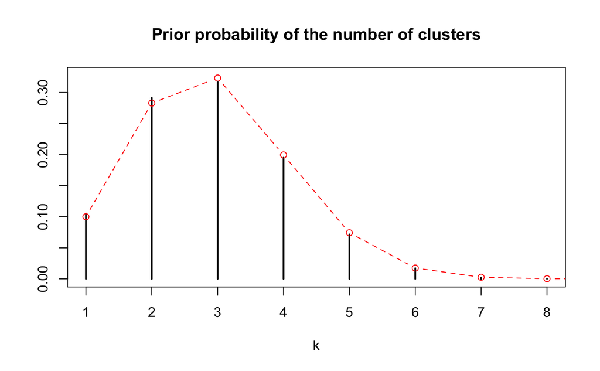

```r
# Compare this MC distribution to the "exact" one - Antoniak 1974 (Ewens formula)
library(gsl) # library gsl to compute log of the Gamma function  lngamma
library(untb) # library containing logS1
#logS1[] e' una matrice che contiene il logaritmo dei numeri di Stirling di primo tipo
# di primo tipo sulla matrice [1:100]*[1:100]
## dato che n=100 la possiamo  utilizzare

pk <- vector(length=n) ## EXACT (analytic) probability                           #  density of K_n  in the log scale
cost.a <- lngamma(a)-lngamma(a+n)
for(l in 1:n){
pk[l] <- logS1[n,l]+l*log(a)+cost.a #logaritmo di pk
}

pk=exp(pk) #probabilities in teh original scale
points(1:n,pk,type="b",col="red",lty=2) # let's plot the  probability masses of the exact distribution of $K_n$
```

Expectation of $K_n$

```r
meanKn= a *sum(1/( a+seq(0,n-1))) # computed via its analytic expression
meanKn
```

```
[1] 2.928968
```

```r
sum(seq(1:n)*pk) # Monte Carlo approximation
```

```
[1] 2.928968
```

How does this distribution change varying $n$ or/and $a$?

When $a$ is SMALL (e.g. $a=0.1$), the sample from the DP yields a few unique values, i.e. the distribution of K_n is concentrated on small values, close to 1

When $a$ is LARGE (e.g. $a=100$), the sample from the DP has may small jumps so that we get larger values for $K_n$